# Praca domowa 6

Piotr Obarski

Modele liniowe i mieszane

Generate continuous variable X_1 from distribution U[0,1]. Generate categorical variable X_2 with 2 levels with equal frequency). Generate Y in a way that it depends on interaction of X_1 and X_2.

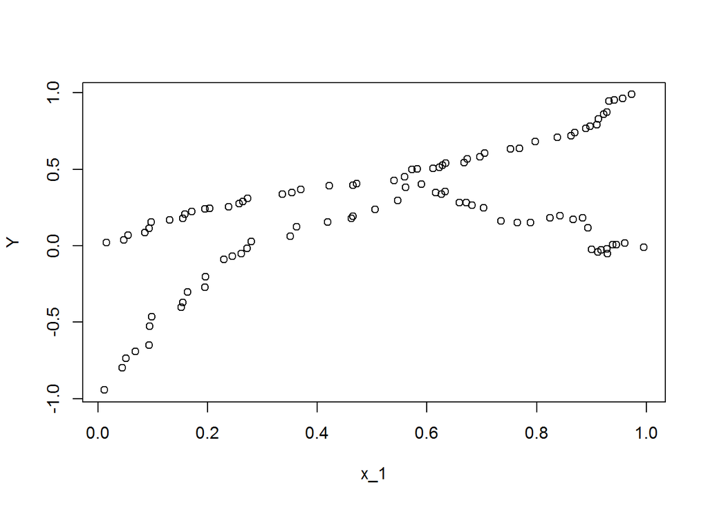

```r
x_1<-runif(100)
x_2<-rep(c(0, 1), 50)
x_1<-sort(x_1)
Y<-sort(runif(100))
Y[seq(1, 50, 2)]<-Y[seq(1, 50, 2)]-sort(runif(25), decreasing=TRUE)
Y[seq(52, 100, 2)]<-Y[seq(52, 100, 2)]-sort(runif(25))
plot(Y~x_1)
```

```r
summary(aov(Y~x_1*x_2))
```

```
##             Df Sum Sq Mean Sq F value Pr(>F)
## x_1          1  5.788   5.788 347.649 <2e-16 ***
## x_2          1  0.091   0.091   5.452 0.0216 *
## x_1:x_2      1  7.995   7.995 480.208 <2e-16 ***
## Residuals   96  1.598   0.017
## ---
## Signif. codes:  0 '***' 0.001 '**' 0.01 '*' 0.05 '.' 0.1 ' ' 1
```

Zatem widzimy, że interakcja jest istotna.

Teraz definiujemy funkcje dla scenariusza 1. tj. dodajemy do Y błędy z rozkładu $\mathcal{N}(0,1)$.

```r
simulation1<-function(n) {
  x_1<-runif(2*n)
  x_2<-rep(c(0, 1), n)
  x_1<-sort(x_1)
  Y<-sort(runif(2*n))
  Y[seq(1, n, 2)]<-Y[seq(1, n, 2)]-sort(runif(length(seq(1,n,2))), decreasing=TRUE)
  Y[seq(ceiling(n/2)*2, 2*n, 2)]<-Y[seq(ceiling(n/2)*2, 2*n, 2)]-sort(runif(length(seq(ceiling(n/2)*2,2*n,2))))
  Y<-Y+rnorm(2*n)
  model<-anova(lm(Y~x_1*x_2))
  shapiro.test(rstandard(lm(Y~x_1*x_2)))$p.value
  return(c(model$"Pr(>F)"[3], shapiro.test(rstandard(lm(Y~x_1*x_2)))$p.value))
}
power1<-function(n, p) {
  pvalues<-replicate(100, simulation1(n))
  c(length(which(pvalues[1,]<p))/100,
  length(which(pvalues[2,]<p))/100)
}
power1(50, 0.05)
```

```
## [1] 0.73 0.04
```

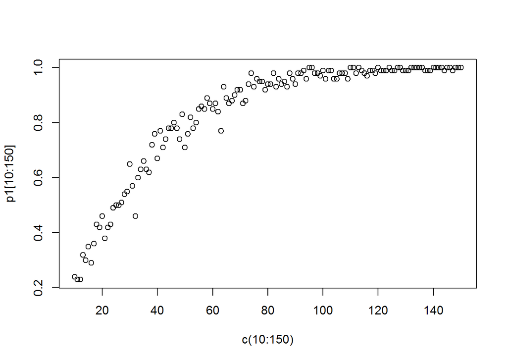

```r
p1<-0
normalnosc1<-0
for(i in 10:150) {
  a<-0
  a<-power1(i, 0.05)
  p1[i]<-a[1]
  normalnosc1[i]<-a[2]
}
plot(p1[10:150]~c(10:150))
```

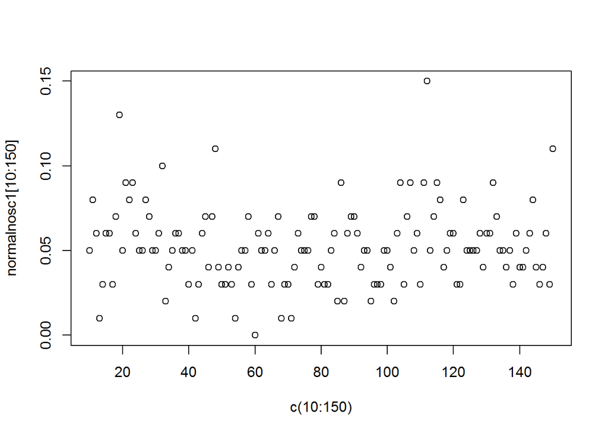

```r
plot(normalnosc1[10:150]~c(10:150))
```

Powyżej otrzymaliśmy wykres mocy testu dla efektu interakcji oraz wielkości błędu typu I w zależności od wielkości próbki.

Teraz scenariusz 2. Jako błąd zostały dodane zmienne ze standardowego rozkładu Cauchyego.

```r
simulation2<-function(n) {
  x_1<-runif(2*n)
  x_2<-rep(c(0, 1), n)
  x_1<-sort(x_1)
  Y<-sort(runif(2*n))
  Y[seq(1, n, 2)]<-Y[seq(1, n, 2)]-sort(runif(length(seq(1,n,2))), decreasing=TRUE)
  Y[seq(ceiling(n/2)*2, 2*n, 2)]<-Y[seq(ceiling(n/2)*2, 2*n, 2)]-sort(runif(length(seq(ceiling(n/2)*2,2*n,2))))
  Y<-Y+rcauchy(2*n, 0, 1)
  model<-anova(lm(Y~x_1*x_2))
  return(c(model$"Pr(>F)"[3], shapiro.test(rstandard(lm(Y~x_1*x_2)))$p.value))
}
power2<-function(n, p) {
  pvalues<-replicate(100, simulation2(n))
  c(length(which(pvalues[1,]<p))/100,
  length(which(pvalues[2,]<p))/100)
  }
power2(50, 0.05)
```

```
## [1] 0.05 1.00
```

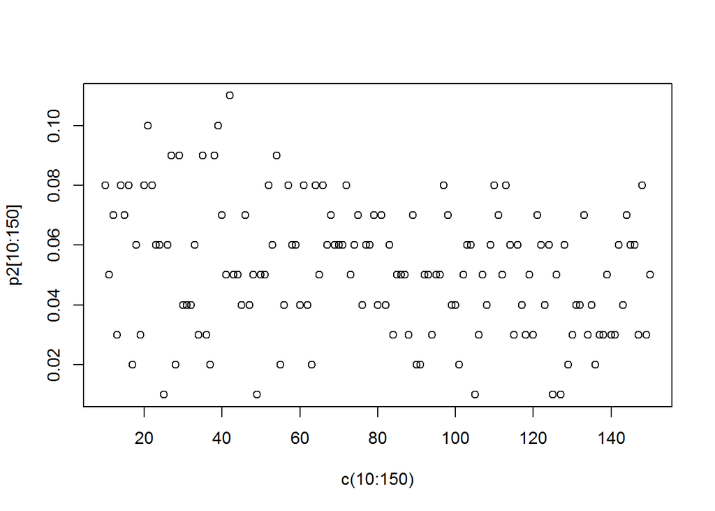

```r
p2<-0
normalnosc2<-0
for(i in 10:150) {
  a<-0
  a<-power2(i, 0.05)
  p2[i]<-a[1]
  normalnosc2[i]<-a[2]
}
plot(p2[10:150]~c(10:150))
```

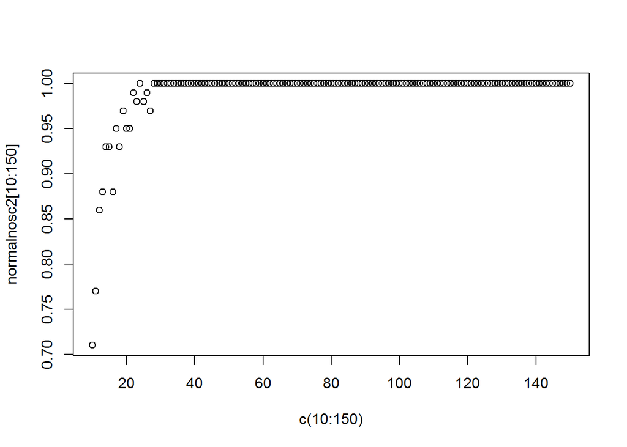

```r
plot(normalnosc2[10:150]~c(10:150))
```

Powyżej wykresy mocy testu dla interakcji oraz moc testu na normalność reszt w zależności od liczności próbki.

W tym scenariusz jako błąd zostały dodane zmienne z rozkładu normalnego $\mathcal{N}(0, 0.01)$.

```r
simulation3<-function(n) {
  x_1<-runif(2*n)
  x_2<-rep(c(0, 1), n)
  x_1<-sort(x_1)
  Y<-sort(runif(2*n))
  Y[seq(1, n, 2)]<-Y[seq(1, n, 2)]-sort(runif(length(seq(1,n,2))), decreasing=TRUE)
  Y[seq(ceiling(n/2)*2, 2*n, 2)]<-Y[seq(ceiling(n/2)*2, 2*n, 2)]-sort(runif(length(seq(ceiling(n/2)*2,2*n,2))))
  Y<-Y+rnorm(2*n)*0.1
  model<-anova(lm(Y~x_1*x_2))
  shapiro.test(rstandard(lm(Y~x_1*x_2)))$p.value
  return(c(model$"Pr(>F)"[3], shapiro.test(rstandard(lm(Y~x_1*x_2)))$p.value))
}
power3<-function(n, p) {
  pvalues<-replicate(100, simulation3(n))
  c(length(which(pvalues[1,]<p))/100,
  length(which(pvalues[2,]<p))/100)
}
power3(50, 0.05)
```

```
## [1] 1.00 0.13
```

```r
p3<-0
normalnosc3<-0
for(i in 10:150) {
  a<-0
  a<-power3(i, 0.05)
  p3[i]<-a[1]
  normalnosc3[i]<-a[2]
}
```

Jak poprzednio, mamy wykresy dla mocy testu dla interakcji oraz dla błędu typu I dla testu na normalność reszt.

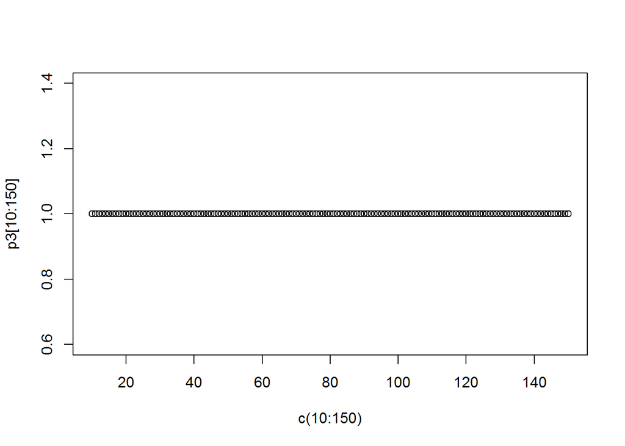

```r
plot(p3[10:150]~c(10:150))
```

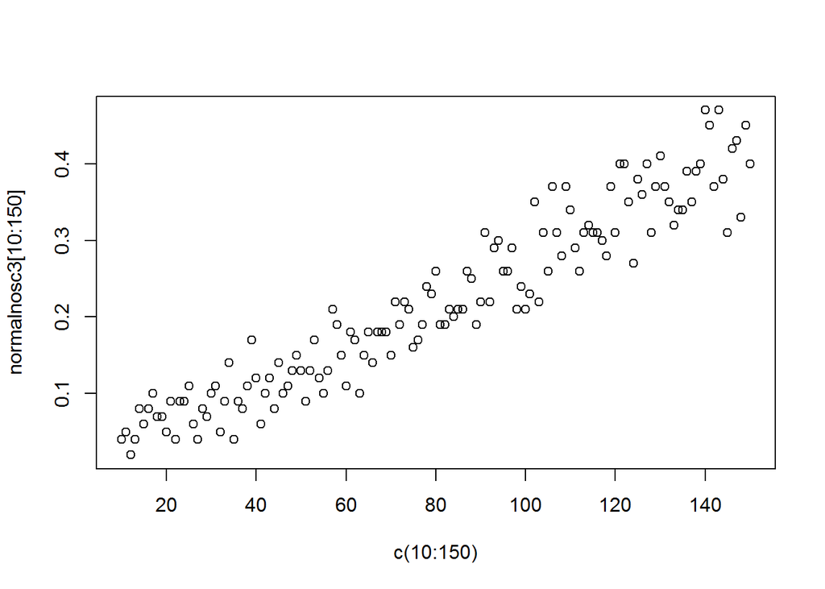

```r
plot(normalnosc3[10:150]~c(10:150))
```

### Wykresy zbiorcze.

Wykres dla mocy testów.

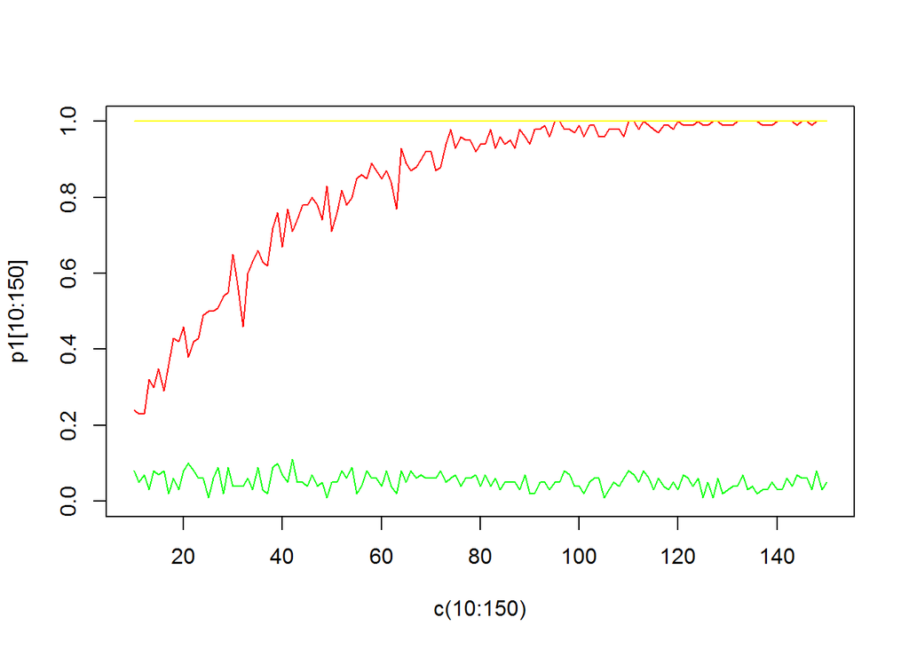

```r
plot(p1[10:150]~c(10:150), type="l",col="red", ylim=c(0, 1))
lines(p2[10:150]~c(10:150), col="green")
lines(p3[10:150]~c(10:150), col="yellow")
```

Wykres wielkości błędu typu I dla normalności rozkładu reszt (scenariusz 1. i scenariusz 3.).

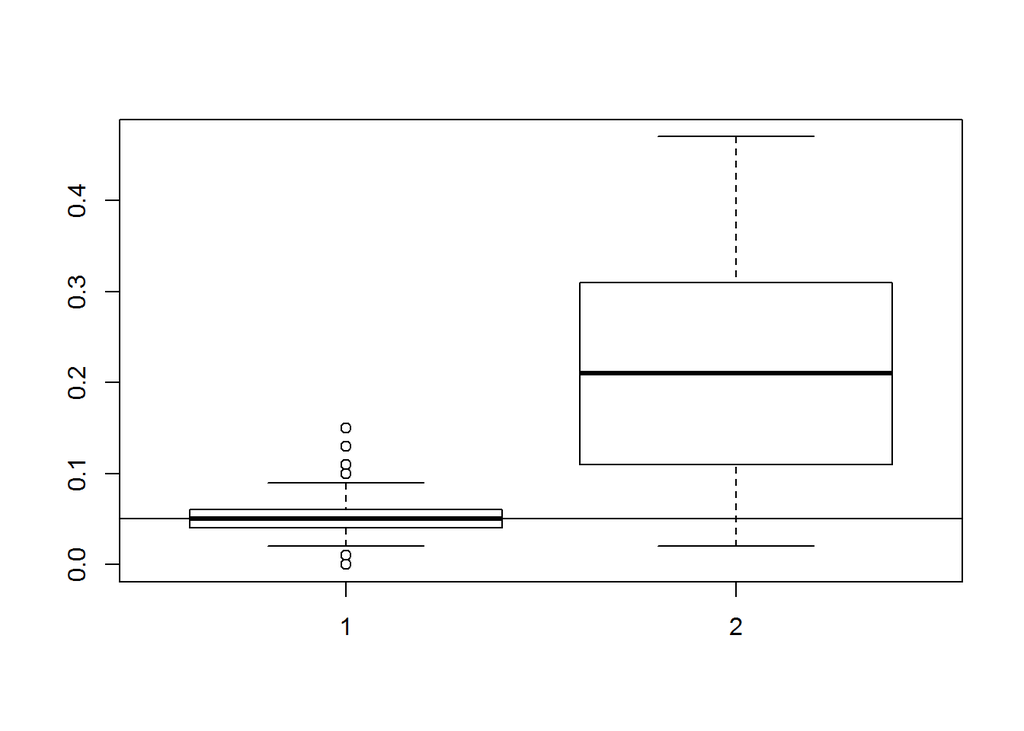

```r
boxplot(normalnosc1[10:150], normalnosc3[10:150])
abline(0.05, 0)
```

## Wnioski

Pierwszy wniosek: melduję wykonanie zadania.  
Drugi wniosek: jeśli rozrzucimy obserwacje zbyt słabo mimo, wydaję się, poprawnych wskazań modelu i wysokiej mocy, diagnostyka modelu może wypaść słabo.  
Wniosek trzeci: jeśli residua nie są z rozkładu normalnego, (w szczególności mają ciężki ogon tak jak rozkład Cauchyego) moc testu nie polepsza się wraz ze zwiększaniem próbki i pozostaje mała.